# COVID-19 Vaccine Analysis

By: Rac Mukkamala, Anish Easwaran

Computer Science Independent Study Final Project

## Introduction

In December 2020, during a large wave of COVID-19 cases, the Pfizer vaccine was granted Emergency Use Authorization by the FDA, and within a week, the Moderna vaccine was also granted an EUA. This paved the way for a large vaccine rollout that began in December 2020. From December to March, the United States experienced a large drop in the number of new daily COVID-19 cases from the peak of more than 240,000 cases per day in January (Source: CDC). We are interested in determining what portion of the recent decline in cases, hospitalizations, and deaths is attributable to the United States’ mass vaccine rollout. We also seek to analyze and contextualize the recent rise in cases in the Midwestern United States, to determine whether this rise is related to gaps in vaccine deployment or, rather, increased risk-taking behavior spurred by the vaccine (Peltzman Effect). We are also interested in exploring vaccine trends across demographic categories such as race, gender, age, and geographic location. We would like to use our findings in these areas to try and empirically confirm the effectiveness of the COVID-19 vaccination campaign, as well as identify potential areas for improvement. Given that certain groups of Americans continue to harbor distrust in the COVID-19 vaccine due to either previous stigma or other beliefs, we also hope that our overall analysis of the current state of the vaccination campaign will help assure individuals in our community that the coronavirus vaccine is safe and effective in the real-world setting.

To analyze the current state of the COVID-19 vaccination campaign, we will be conducting a large-scale exploratory data analysis of publicly available COVID-19 data from the Our World in Data (OWID) project. The GitHub repository for the OWID COVID data is provided [here.](https://github.com/owid/covid-19-data) For our project, we will be parsing the OWID datasets for data on COVID-19 cases, deaths, hospitalizations, vaccinations, and more. After parsing and cleaning the data, we will create plots which summarize key correlations between factors such as vaccine rollout and number of COVID deaths. We will also attempt to fit simple linear, logistic, or polynomial regression models to our data, and conduct statistical hypothesis testing on our data using Python statistics packages.

## Data and Package Loading

**Run the script below to import key Python packages**. Note: The initial exploratory plotting will be using the plotnine ggplot-based graphics package, and the correlation section will be using matplotlib. This choice makes plotting much easier in each respective scenario.

```python
from plotnine import *
from IPython.display import display
from dateutil.parser import *
import pandas
from mizani.breaks import date_breaks
import numpy as np
from sklearn.metrics import r2_score
import matplotlib.pyplot as plt
from scipy.optimize import curve_fit
import scipy
plt.rcParams['figure.figsize'] = [10, 8]
plt.rcParams['axes.titlesize'] = 18
plt.rcParams['axes.labelsize'] = 14
```

**Run the script below to download the latest version of the OWID COVID dataset from GitHub.**

```python
url = 'https://raw.githubusercontent.com/owid/covid-19-data/master/public/data/owid-covid-data.csv'
world_covid = pandas.read_csv(url, parse_dates=['date'])
covid_usa_temp = world_covid[world_covid['iso_code'] == 'USA']
```

## Initial Data Exploration

The plots below are intended to give a general picture of the current COVID situation in the United States. Over the past few months, cases and deaths have been declining as the number of vaccine doses administered steadily rose. We will be presenting 7-day smoothed data, rather than raw data, since raw daily COVID data has lots of extra noise [(see reference here).](https://towardsdatascience.com/five-wrong-ways-to-do-covid-19-data-smoothing-1538db6ff182)

Below is a plot of total vaccinations in the United States over the past four months.

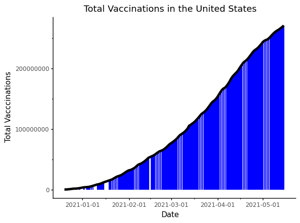

```python
covid_usa = covid_usa_temp.dropna(subset=['total_vaccinations'])
(ggplot(covid_usa, aes(x='date', y='total_vaccinations'))
 + geom_col(fill='blue')
 + geom_line(color='black', size=2)
 + scale_x_datetime(breaks=date_breaks('1 month'))
 + ggtitle('Total Vaccinations in the United States')
 + labs(x = 'Date', y = 'Total Vacccinations')
 + theme_classic()
)
```

Below is a plot of new daily COVID cases over the past four months while vaccinations were occurring.

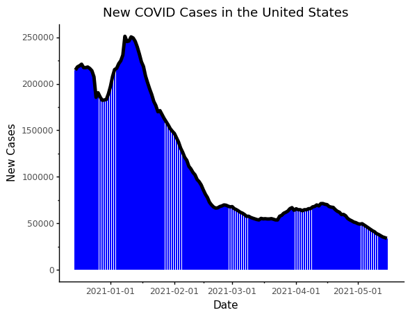

```python
covid_usa = covid_usa_temp.dropna(subset=['new_cases_smoothed'])
covid_usa = covid_usa[covid_usa['date'] > parse('12-14-2020')]
(ggplot(covid_usa, aes(x='date', y='new_cases_smoothed'))
 + geom_col(fill="blue")
 + geom_line(color="black", size=2)
 + scale_x_datetime(breaks=date_breaks('1 month'))
 + ggtitle('New COVID Cases in the United States')
 + labs(x = 'Date', y = 'New Cases')
 + theme_classic()
)
```

Lastly, below is a plot of new COVID deaths over this same period.

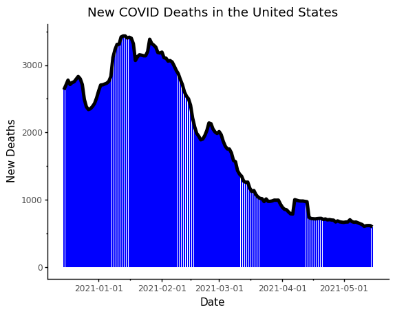

```python
covid_usa = covid_usa_temp.dropna(subset=['new_deaths_smoothed'])
covid_usa = covid_usa[covid_usa['date'] > parse('12-14-2020')]
(ggplot(covid_usa, aes(x='date', y='new_deaths_smoothed'))
 + geom_col(fill='blue')
 + geom_line(color='black', size=2)
 + scale_x_datetime(breaks=date_breaks('1 month'))
 + ggtitle('New COVID Deaths in the United States')
 + labs(x = 'Date', y = 'New Deaths')
 + theme_classic()
)
```

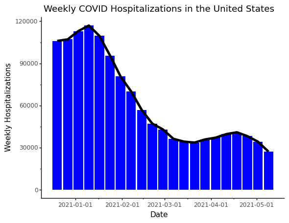

```python
covid_usa = covid_usa_temp.dropna(subset=['weekly_hosp_admissions'])
covid_usa = covid_usa[covid_usa['date'] > parse('12-14-2020')]
(ggplot(covid_usa, aes(x='date', y='weekly_hosp_admissions'))
 + geom_col(fill='blue')
 + geom_line(color='black', size=2)
 + scale_x_datetime(breaks=date_breaks('1 month'))
 + ggtitle('Weekly COVID Hospitalizations in the United States')
 + labs(x = 'Date', y = 'Weekly Hospitalizations')
 + theme_classic()
)
```

## Correlations and Fitting Models

In order to improve predictive power and replicability, all of the correlations we model below will use per capita rates. This allows us to easily apply data from the US to other countries which may be larger or smaller in total population. We will also be using 7-day smoothed data to reduce noise. Lastly, we will be using data on the percentage of people fullly vaccinated, rather than just raw total vaccinations, to model the effects of declining susceptibility of the US population to the virus.

```
[ 4.11096612e-03 -3.61688254e-01  1.07402729e+01 -1.24052987e+02
  6.40413765e+02]
R^2 = 0.969
```

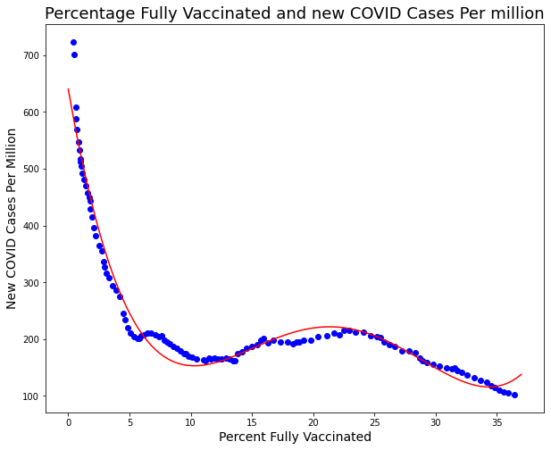

```python
covid_usa = covid_usa_temp.dropna(subset=['people_fully_vaccinated_per_hundred', 'new_cases_smoothed_per_million'])
#define quartic model
def quartic(x, a, b, c, d, e):
  return a*np.power(x,4) + b*np.power(x,3) + c*np.power(x,2) + d*x + e
#define initial conditions
p0 = [0.001149, -0.1132, 3.759, -49.23, 320.4]
#scipy optimize
popt, pcov = curve_fit(f=quartic, xdata=covid_usa['people_fully_vaccinated_per_hundred'].tolist(), ydata=covid_usa['new_cases_smoothed_per_million'].tolist(), p0=p0, method='dogbox')
print(popt)
#r2 value
r2 = r2_score(covid_usa['new_cases_smoothed_per_million'], quartic(covid_usa['people_fully_vaccinated_per_hundred'], popt[0], popt[1], popt[2], popt[3], popt[4]))
print(f'R^2 = {round(r2, 3)}')

fig, ax = plt.subplots()
ax.set_title("Percentage Fully Vaccinated and new COVID Cases Per million")
ax.set_ylabel("New COVID Cases Per Million")
ax.set_xlabel("Percent Fully Vaccinated")
ax.plot(covid_usa['people_fully_vaccinated_per_hundred'], covid_usa['new_cases_smoothed_per_million'], 'o', color="blue")
xvals = np.linspace(0, 37, 100)
ax.plot(xvals, quartic(xvals, popt[0], popt[1], popt[2], popt[3], popt[4]), 'r-')
plt.show()
```

Secondly, here is a look at the relationship between percent fully vaccinated and new COVID deaths per million. This relationship clearly appeared to follow an exponential decay model, so we used SciPy's curve_fit() function to optimize the parameters of an exponential decay model for the data given. Given this model's high strength of association (R^2 = 0.98), we can predict that the number of deaths per million will eventually level out to an ideal value of 1.78 per million.

```
y = 9.2*e^(-0.124x) + 1.783
R^2 = 0.982
```

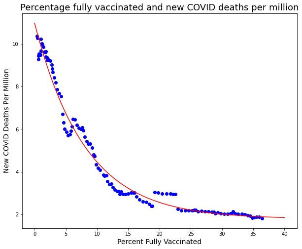

```python
covid_usa = covid_usa_temp.dropna(subset=['people_fully_vaccinated_per_hundred', 'new_deaths_smoothed_per_million'])

#exponential decay model
def exp(x, A, k, c):
  return A*np.exp(-1*k*x) + c
#initial guess
p0 = [9, 0.08, 2]
#scipy optimize
popt, pcov = curve_fit(f=exp, xdata=covid_usa['people_fully_vaccinated_per_hundred'], ydata=covid_usa['new_deaths_smoothed_per_million'], p0=p0, method='lm')
print(f'y = {round(popt[0],3)}*e^(-{round(popt[1],3)}x) + {round(popt[2], 3)}')
#r^2 of model
r2 = r2_score(covid_usa['new_deaths_smoothed_per_million'], exp(covid_usa['people_fully_vaccinated_per_hundred'], popt[0], popt[1], popt[2]))
print(f'R^2 = {round(r2, 3)}')
#plot
fig, ax = plt.subplots()
ax.set_title("Percentage fully vaccinated and new COVID deaths per million")
ax.set_ylabel("New COVID Deaths Per Million")
ax.set_xlabel("Percent Fully Vaccinated")
ax.plot((covid_usa['people_fully_vaccinated_per_hundred']), ((covid_usa['new_deaths_smoothed_per_million'])), 'bo')
xvals = np.linspace(0, 40, 200)
ax.plot(xvals, exp(xvals, popt[0], popt[1], popt[2]), 'r-')
plt.show()
```

```
          4          3         2
0.001056 x - 0.1066 x + 3.622 x - 48.37 x + 322.3
R^2 = 0.995
```

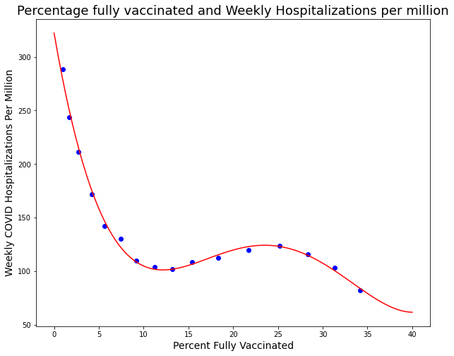

```python
covid_usa = covid_usa_temp.dropna(subset=['weekly_hosp_admissions_per_million','people_fully_vaccinated_per_hundred'])
model_hosp_fullvacc = np.poly1d(np.polyfit(covid_usa['people_fully_vaccinated_per_hundred'], covid_usa['weekly_hosp_admissions_per_million'], 4))
xvals = np.linspace(0, 40, 100)
print(model_hosp_fullvacc)

r2 = r2_score(covid_usa['weekly_hosp_admissions_per_million'], model_hosp_fullvacc(covid_usa['people_fully_vaccinated_per_hundred']))
print(f'R^2 = {round(r2, 3)}')

fig, ax = plt.subplots()
ax.set_title("Percentage fully vaccinated and Weekly Hospitalizations per million")
ax.set_ylabel("Weekly COVID Hospitalizations Per Million")
ax.set_xlabel("Percent Fully Vaccinated")
ax.plot(covid_usa['people_fully_vaccinated_per_hundred'], covid_usa['weekly_hosp_admissions_per_million'], 'bo')
ax.plot(xvals, model_hosp_fullvacc(xvals), 'r-')
plt.show()
```

## Vaccine Predictions

We are also interested in tracking the progress of completed vaccinations in the United States. We believe that the progress of vaccinations over time would follow a sigmoid/logistic model, where the number of vaccinations will increase rapidly at first, but as more and more people get vaccinated the rate would begin slowing down. Using scipy's curve_fit optimizer with a logistic model, we were able to create a model that, once again, had a near perfect fit with a R^2 of 0.999.

```
y = 62.088/(1 + e^-0.029(x-101.547)) + -2.963
R^2 = 0.999
US Final Estimated Percent Fully Vaccinated: 62.09%
US Predicted days til Peak: 204.0 days from start
```

[figure not shown]

```python
covid_usa = covid_usa_temp.dropna(subset=['people_fully_vaccinated_per_hundred', 'date'])
covid_usa = covid_usa.assign(date = (covid_usa['date'] - parse('01-14-2021')).dt.days)

#structure of logistic function
def logistic(x, L, k, C, x0):
  return (L/(1 + np.exp(-1*k*(x-x0)))) + C

#initial guess for model
p0 = [60, 0.05, 0, 100]
popt, pcov = curve_fit(f=logistic, xdata=covid_usa['date'].tolist(), ydata=covid_usa['people_fully_vaccinated_per_hundred'].tolist(), p0=p0, method = 'lm')
print(f'y = {round(popt[0], 3)}/(1 + e^-{round(popt[1], 3)}(x-{round(popt[3], 3)})) + {round(popt[2], 3)}')

r2 = r2_score(covid_usa['people_fully_vaccinated_per_hundred'], logistic(covid_usa['date'], *popt))
print(f'R^2 = {round(r2,3)}')

fig, ax = plt.subplots()
ax.plot(covid_usa['date'], covid_usa['people_fully_vaccinated_per_hundred'], 'bo', markersize=4)
xvals = np.linspace(0, 120, 200)
ax.plot(xvals, logistic(xvals, *popt), 'r-', linewidth=3)
ax.set_title("Percentage fully vaccinated since January 14th, 2021")
ax.set_xlabel("Days since 01/14/2021")
ax.set_ylabel("Percent Fully Vaccinated")

print('US Final Estimated Percent Fully Vaccinated: ' + str(round(popt[0], 2)) + '%')
print('US Predicted days til Peak: ' + str(round(popt[3], 0)*2) + ' days from start')
plt.show()
```

Our logistic model predicts that by around August 2021, the United States will have fully vaccinated a peak of 62.1% of the population. This current prediction is below the Biden Administration's Target of 70% of all Americans vaccinated by July 4th, and so governments across the country will need to ramp up outreach efforts in order raise the curve and meet the 70% target.

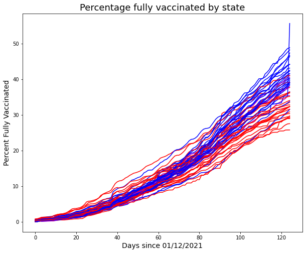

```python
url = 'https://raw.githubusercontent.com/owid/covid-19-data/master/public/data/vaccinations/us_state_vaccinations.csv'
usa_statevacc = pandas.read_csv(url, parse_dates=['date'])
usa_statevacc = usa_statevacc.dropna(subset=['people_fully_vaccinated_per_hundred', 'date'])
usa_statevacc = usa_statevacc.assign(date = (usa_statevacc['date'] - parse('01-12-2021')).dt.days)

states = {'Alabama':'r', 'Alaska':'r', 'Arizona':'r', 'Arkansas':'r', 'California':'b',
           'Colorado':'b', 'Connecticut':'b', 'Delaware':'b', 'District of Columbia':'b',
           'Florida':'m', 'Georgia':'r', 'Hawaii':'b', 'Idaho':'r', 'Illinois':'b',
           'Indiana':'r', 'Iowa':'m', 'Kansas':'r', 'Kentucky':'r', 'Louisiana':'r',
           'Maine':'b', 'Maryland':'b', 'Massachusetts':'b', 'Michigan':'b', 'Minnesota':'b',
          'Mississippi':'r', 'Missouri':'r', 'Montana':'r', 'Nebraska':'r', 'Nevada':'b',
           'New Hampshire':'b', 'New Jersey':'b', 'New Mexico':'b', 'New York State':'b',
           'North Carolina':'r', 'North Dakota':'r', 'Ohio':'m', 'Oklahoma':'r', 'Oregon':'b',
           'Pennsylvania':'b', 'Puerto Rico':'b', 'Rhode Island':'b', 'South Carolina':'r',
           'South Dakota':'r', 'Tennessee':'r', 'Texas':'r', 'Utah':'r', 'Vermont':'b',
          'Virginia':'b', 'Washington':'b', 'West Virginia':'r', 'Wisconsin':'b', 'Wyoming':'r'}

fig, ax = plt.subplots()
ax.set_title("Percentage fully vaccinated by state")
ax.set_xlabel("Days since 01/12/2021")
ax.set_ylabel("Percent Fully Vaccinated")

for state in states.keys():
  usa_statevacc_state = usa_statevacc[usa_statevacc['location'] == state]
  ax.plot(usa_statevacc_state['date'], usa_statevacc_state['people_fully_vaccinated_per_hundred'], bluered[state]+'-')
```

Using state-by-state data, we fitted a logistic model to each state's vaccination data in order to predict state and national total percent vaccinations with more local, refined data. Once again, model trendlines are colored by the state's general political leaning. When models were fit to each state's data, there were some erroneous results, such as predictions that 140% of Oregon residents would be vaccinated. Additionally, the logistic curve for Georgia had an extremely erroneous result (prediction of 900 million total vaccinations in a state of 10 million), and since the Scipy optimize function could not converge within the max number of iterations, Georgia's data needed to be dropped.

```
Logistic Curve Fit failed for Georgia
Data for Georgia will unfortunately need to be dropped
```

|  | State | Predicted_Number_Fully_Vaccinated | Predicted_Percent_Fully_Vaccinated | Predicted_Elapsed_Time | Political_Slant |
| --- | --- | --- | --- | --- | --- |
| 0 | Alabama | 2544152.0 | 51.86 | 202.0 | Red |
| 1 | Alaska | 435871.0 | 59.58 | 144.0 | Red |
| 2 | Arizona | 3423979.0 | 47.05 | 170.0 | Red |
| 3 | Arkansas | 1443203.0 | 47.83 | 194.0 | Red |
| 4 | California | 24979628.0 | 63.23 | 212.0 | Blue |
| 5 | Colorado | 8682429.0 | 150.46 | 326.0 | Blue |
| 6 | Connecticut | 2830946.0 | 79.39 | 212.0 | Blue |
| 7 | Delaware | 769984.0 | 79.02 | 232.0 | Blue |
| 8 | District of Columbia | 438797.0 | 62.18 | 224.0 | Blue |
| 9 | Florida | 19589398.0 | 91.22 | 262.0 | Purple |
| 10 | Hawaii | 1616129.0 | 114.20 | 264.0 | Blue |
| 11 | Idaho | 731527.0 | 40.94 | 160.0 | Red |
| 12 | Illinois | 6519551.0 | 51.45 | 186.0 | Blue |
| 13 | Indiana | 3951582.0 | 58.70 | 190.0 | Red |
| 14 | Iowa | 1648749.0 | 52.26 | 176.0 | Purple |
| 15 | Kansas | 1443166.0 | 49.54 | 182.0 | Red |
| 16 | Kentucky | 2126166.0 | 47.59 | 172.0 | Red |
| 17 | Louisiana | 1917629.0 | 41.26 | 162.0 | Red |
| 18 | Maine | 960329.0 | 71.44 | 200.0 | Blue |
| 19 | Maryland | 4933945.0 | 81.60 | 228.0 | Blue |
| 20 | Massachusetts | 5910047.0 | 85.72 | 226.0 | Blue |
| 21 | Michigan | 7552199.0 | 75.65 | 228.0 | Blue |
| 22 | Minnesota | 3385546.0 | 60.02 | 190.0 | Blue |
| 23 | Mississippi | 983406.0 | 33.04 | 144.0 | Red |
| 24 | Missouri | 2878272.0 | 46.89 | 186.0 | Red |
| 25 | Montana | 513849.0 | 48.08 | 166.0 | Red |
| 26 | Nebraska | 1231665.0 | 63.68 | 198.0 | Red |
| 27 | Nevada | 1624392.0 | 52.75 | 188.0 | Blue |
| 28 | New Hampshire | 701201.0 | 51.58 | 182.0 | Blue |
| 29 | New Jersey | 6045514.0 | 68.09 | 200.0 | Blue |
| 30 | New Mexico | 1446549.0 | 69.01 | 174.0 | Blue |
| 31 | New York State | 11558022.0 | 59.40 | 196.0 | Blue |
| 32 | North Carolina | 6268992.0 | 59.77 | 198.0 | Red |
| 33 | North Dakota | 321846.0 | 42.24 | 152.0 | Red |
| 34 | Ohio | 7456106.0 | 63.78 | 202.0 | Purple |
| 35 | Oklahoma | 1774409.0 | 44.85 | 156.0 | Red |
| 36 | Oregon | 5949366.0 | 140.90 | 326.0 | Blue |
| 37 | Pennsylvania | 7313574.0 | 57.13 | 198.0 | Blue |
| 38 | Puerto Rico | 3198636.0 | 100.27 | 304.0 | Blue |
| 39 | Rhode Island | 542271.0 | 51.19 | 172.0 | Blue |
| 40 | South Carolina | 2474645.0 | 48.07 | 184.0 | Red |
| 41 | South Dakota | 489701.0 | 55.35 | 168.0 | Red |
| 42 | Tennessee | 3774121.0 | 55.29 | 222.0 | Red |
| 43 | Texas | 14225942.0 | 49.05 | 200.0 | Red |
| 44 | Utah | 1724661.0 | 53.80 | 228.0 | Red |
| 45 | Vermont | 458203.0 | 73.43 | 210.0 | Blue |
| 46 | Virginia | 8525496.0 | 99.97 | 258.0 | Blue |
| 47 | Washington | 4872447.0 | 63.99 | 200.0 | Blue |
| 48 | West Virginia | 1040827.0 | 58.12 | 168.0 | Red |
| 49 | Wisconsin | 3863330.0 | 66.37 | 196.0 | Blue |
| 50 | Wyoming | 234855.0 | 40.58 | 140.0 | Red |

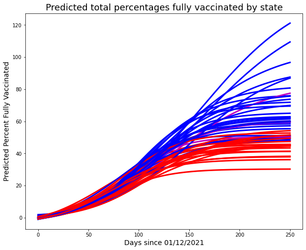

```
US Estimated Total Number of People to Be Fully Vaccinated: 209327250.0
US Estimated Total Percentage of People to Be Fully Vaccinated: 63.78%
```

```python
#structure of logistic function
def logistic(x, L, k, C, x0):
  return (L/(1 + np.exp(-1*k*(x-x0)))) + C

state_pred = {'State':[], 'Predicted_Number_Fully_Vaccinated':[], 'Predicted_Percent_Fully_Vaccinated':[], 'Predicted_Elapsed_Time':[], 'Political_Slant':[]}

fig, ax = plt.subplots()
ax.set_title("Predicted total percentages fully vaccinated by state")
ax.set_xlabel("Days since 01/12/2021")
ax.set_ylabel("Predicted Percent Fully Vaccinated")
xvals = np.linspace(0, 250, 200)

for state in states.keys():
  usa_statevacc_state = usa_statevacc[usa_statevacc['location'] == state]
  #initial model guess
  p0 = [10000000, 0.03, 0, 70]
  #fitted logistic curve for each state
  try:
    popt, pcov = curve_fit(f=logistic, xdata=usa_statevacc_state['date'].tolist(), ydata=usa_statevacc_state['people_fully_vaccinated'].tolist(), p0=p0, method = 'dogbox', maxfev=5000)
    popt_percent, pcov = curve_fit(f=logistic, xdata=usa_statevacc_state['date'].tolist(), ydata=usa_statevacc_state['people_fully_vaccinated_per_hundred'].tolist(), p0=p0, method = 'dogbox', maxfev=5000)
    state_pred['State'].append(state)
    state_pred['Predicted_Number_Fully_Vaccinated'].append(round(popt[0], 0))
    state_pred['Predicted_Percent_Fully_Vaccinated'].append(round(popt_percent[0], 2))
    state_pred['Predicted_Elapsed_Time'].append(round(popt[3], 0)*2)
    if states[state] == 'b':
      state_pred['Political_Slant'].append('Blue')
    elif states[state] == 'r':
      state_pred['Political_Slant'].append('Red')
    else:
      state_pred['Political_Slant'].append('Purple')

    ax.plot(xvals, logistic(xvals, *popt_percent), states[state] + '-', linewidth=3)
  except:
    print('Logistic Curve Fit failed for ' + state)
    print('Data for ' + state + ' will unfortunately need to be dropped')

state_pred = pandas.DataFrame(data=state_pred)
display(state_pred)
plt.show()
us_total = np.sum(state_pred['Predicted_Number_Fully_Vaccinated'].to_numpy())
us_pop = 328200000
print('US Estimated Total Number of People to Be Fully Vaccinated: ' + str(us_total))
print('US Estimated Total Percentage of People to Be Fully Vaccinated: ' + str(round(us_total/us_pop*100,3)) + '%')
```

The two plots below attempt to predict the total number of vaccine doses that will be administered in the US using two unique methods. The first method (shown below) fitted two linear models to the number of new doses per day, and integrated across the two linear models (found the area under the predicted triangle) to model the predicted total number of vaccinations. This approach is valid since the integral of the rate of new vaccines per day over the total time interval yields the total sum of vaccination doses.

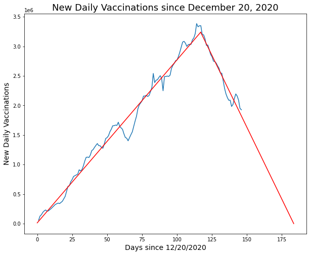

```
Predicted total number of vaccinations administered: 297852214.0
```

```python
covid_usa = covid_usa_temp.dropna(subset=['new_vaccinations_smoothed', 'date'])
covid_usa = covid_usa.assign(date = (covid_usa['date'] - parse('12-20-2020')).dt.days)

fig, ax = plt.subplots()
ax.set_title("New Daily Vaccinations since December 20, 2020")
ax.set_xlabel("Days since 12/20/2020")
ax.set_ylabel("New Daily Vaccinations")
ax.plot(covid_usa['date'], covid_usa['new_vaccinations_smoothed'])

maxval = max(covid_usa[covid_usa['date'] > 0]['new_vaccinations_smoothed'])
maxdate = int(covid_usa[covid_usa['new_vaccinations_smoothed'] == maxval]['date'])

covid_usa_beforepeak = covid_usa[covid_usa['date'] <= maxdate]
covid_usa_afterpeak = covid_usa[covid_usa['date'] > maxdate]

model_beforepeak = np.poly1d(np.polyfit(covid_usa_beforepeak['date'], covid_usa_beforepeak['new_vaccinations_smoothed'], 1))
model_afterpeak = np.poly1d(np.polyfit(covid_usa_afterpeak['date'], covid_usa_afterpeak['new_vaccinations_smoothed'], 1))

def intersection(line1, line2):
  xval = (line1[0] - line2[0])/(line2[1] - line1[1])
  yval = line1(xval)
  return xval, yval

xint, yint = intersection(model_beforepeak, model_afterpeak)
zerox = -1*model_afterpeak[0]/model_afterpeak[1]

before = np.linspace(0, xint, 100)
after = np.linspace(xint, zerox, 100)

ax.plot(before, model_beforepeak(before), 'r-')
ax.plot(after, model_afterpeak(after), 'r-')
plt.show()

total_vacc = scipy.integrate.quad(model_beforepeak, 0, xint)[0] + scipy.integrate.quad(model_afterpeak, xint, zerox)[0]
print('Predicted total number of vaccinations administered: ' + str(round(total_vacc, 0)))
```

The second approach (shown below) fits a logistic model to the tally of total vaccinations updated each day.

```
y = 380234508.431/(1 + e^-0.031(x-108.765)) + -14147731.272
R^2 = 1.0
Predicted total number of vaccinations administered: 380234508.0
```

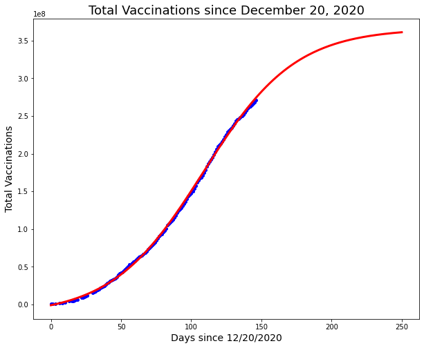

```python
covid_usa = covid_usa_temp.dropna(subset=['total_vaccinations', 'date'])
covid_usa = covid_usa.assign(date = (covid_usa['date'] - parse('12-20-2020')).dt.days)

#structure of logistic function
def logistic(x, L, k, C, x0):
  return (L/(1 + np.exp(-1*k*(x-x0)))) + C

#initial guess for model
p0 = [300000000, 0.05, 0, 100]
popt, pcov = curve_fit(f=logistic, xdata=covid_usa['date'].tolist(), ydata=covid_usa['total_vaccinations'].tolist(), p0=p0, method = 'lm')
print(f'y = {round(popt[0], 3)}/(1 + e^-{round(popt[1], 3)}(x-{round(popt[3], 3)})) + {round(popt[2], 3)}')

r2 = r2_score(covid_usa['total_vaccinations'], logistic(covid_usa['date'], *popt))
print(f'R^2 = {round(r2,3)}')

fig, ax = plt.subplots()
ax.set_title("Total Vaccinations since December 20, 2020")
ax.set_xlabel("Days since 12/20/2020")
ax.set_ylabel("Total Vaccinations")

ax.plot(covid_usa['date'], covid_usa['total_vaccinations'], 'bo', markersize=4)
xvals = np.linspace(0, 250, 200)
ax.plot(xvals, logistic(xvals, *popt), 'r-', linewidth=3)
print('Predicted total number of vaccinations administered: ' + str(round(popt[0], 0)))
plt.show()
```

## Vaccine Breakdown by Manufacturer

Loading data for US vaccinations by manufacturer:

```python
url = 'https://raw.githubusercontent.com/owid/covid-19-data/master/public/data/vaccinations/vaccinations-by-manufacturer.csv'
world_vacc_mfr = pandas.read_csv(url, parse_dates=['date'])
vacc_usa_mfr = world_vacc_mfr[world_vacc_mfr['location'] == 'United States']
vacc_usa_pfizer = vacc_usa_mfr[world_vacc_mfr['vaccine'] == 'Pfizer/BioNTech']
vacc_usa_johnson = vacc_usa_mfr[world_vacc_mfr['vaccine'] == 'Johnson&Johnson']
vacc_usa_moderna = vacc_usa_mfr[world_vacc_mfr['vaccine'] == 'Moderna']
```

Below is the total number of Johnson and Johnson vaccinations administered over the past few months. The plateau in J&J vaccinations in mid-April is likely due to the temporary halt in J&J vaccine administration due to incidence of blood clots in certain patients.

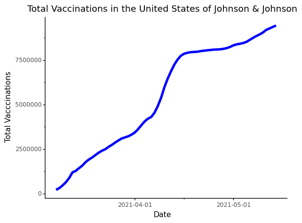

```python
(ggplot(vacc_usa_johnson, aes(x='date', y='total_vaccinations'))
 + geom_line(color='blue', size=2)
 + scale_x_datetime(breaks=date_breaks('1 month'))
 + ggtitle('Total Vaccinations in the United States of Johnson & Johnson')
 + labs(x = 'Date', y = 'Total Vacccinations')
 + theme_classic()
)
```

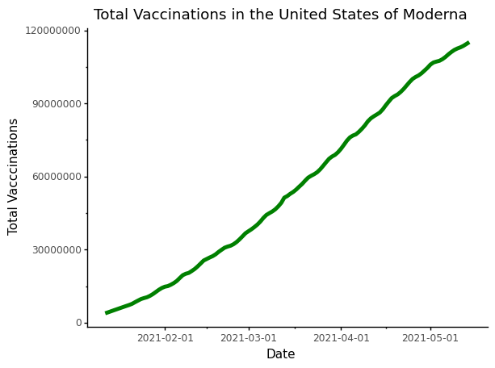

```python
(ggplot(vacc_usa_moderna, aes(x='date', y='total_vaccinations'))
 + geom_line(color='green', size=2)
 + scale_x_datetime(breaks=date_breaks('1 month'))
 + ggtitle('Total Vaccinations in the United States of Moderna')
 + labs(x = 'Date', y = 'Total Vacccinations')
 + theme_classic()
)
```

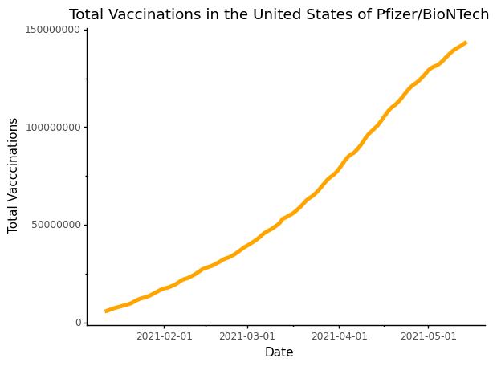

```python
(ggplot(vacc_usa_pfizer, aes(x='date', y='total_vaccinations'))
 + geom_line(color='orange', size=2)
 + scale_x_datetime(breaks=date_breaks('1 month'))
 + ggtitle('Total Vaccinations in the United States of Pfizer/BioNTech')
 + labs(x = 'Date', y = 'Total Vacccinations')
 + theme_classic()
)
```

Now, to compare each of the manufacturer's vaccination rates in the United States.

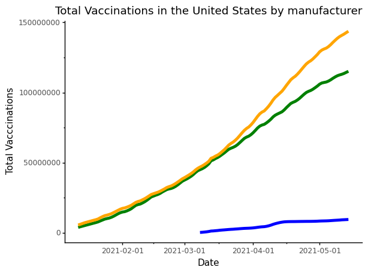

```python
(ggplot(vacc_usa_mfr, aes(x='date', y='total_vaccinations'))
 + geom_line(vacc_usa_mfr[world_vacc_mfr['vaccine'] == 'Johnson&Johnson'], color='blue', size=2)
 + geom_line(vacc_usa_mfr[world_vacc_mfr['vaccine'] == 'Moderna'], color='green', size=2)
 + geom_line(vacc_usa_mfr[world_vacc_mfr['vaccine'] == 'Pfizer/BioNTech'], color='orange', size=2)
 + scale_x_datetime(breaks=date_breaks('1 month'))
 + ggtitle('Total Vaccinations in the United States by manufacturer')
 + labs(x = 'Date', y = 'Total Vacccinations')
 + theme_classic()
)
```

As can be seen, while the Pfizer and Moderna vaccines have rapidly accelerated in deployment and have been adminstered to well over 100 million doses each. However, the Johnson & Johnson vaccine has severly lagged behind in both rate of increase and total vaccination numbers.

## Conclusions

### The effects of Vaccinations

After looking at correlations between percentage fully vaccinated in the United States and new cases, hospitalizations, and deaths, we observed strong associations between vaccinated percentages and the decline of these COVID metrics. The strong observations we observed lines up with the science behind vaccinations, and shows that vaccinations have been associated with a significant positive impact on the United States' COVID situation.

When we fit polynomial models to caseload and hospitalization data, we observed a brief rise in hospitalizations and cases during April, when the US was roughly 20-30% vaccinated. During this period, however, there was no associated rise in COVID deaths, in fact, COVID deaths continued to decline during April. The implications of these findings are twofold. Firstly, the lack of rise in COVID deaths during the COVID peak in April demonstrates the positive association of vaccinations with the prevention of serious illness. Secondly, though, this rise in cases serves as a warning against excessive complacency while vaccinations are still below the herd immunity threshold. If anything, the success associated with vaccinations should motivate the United States population to double down until they receive their vaccination dose, at which point they can relax social distancing and begin returning to normalcy. As the US continues to make great inroads in the fight against COVID, we must ensure that we do not let our guard down and let all of our hard work this past year go to waste.

### Total Vaccinations and Vaccination Percentages

As with all other predictors of COVID-19 metrics, our predictions of final vaccination metrics are in no means final or accurate. In fact, as we continued to build our model over the course of a few weeks, we noticed that our final predictions gradually began to decrease as new data came in. However, what we can say with certainty is that the data for vaccinations in the United States are following a clear logistic trend, since new vaccination rates have definitely begun to level off and decline. As of May 16th, 2021, we predict that 60-65% of the US population will get fully vaccination, which, as mentioned earlier, falls short of President Biden's recently announced target of 70% vaccinated by July 4th.

When we broke down vaccination data and predictions by state, there was a very clear divide between vaccination percentages in red/Republican leaning states and blue/Democratic leaning states. Although we do not wish to venture into politicized arguments, we do believe that the disparities observed in vaccination percentages are attributable to the current political climate. Our main stance is that given the remarkable declines in deaths and new cases our country has observed since beginning the vaccine rollout, we believe that every effort should be taken to ensure that the issue of vaccinations is not politicized. These actions are essential to ensure that all states are able to finally turn the corner on their COVID situations.

### Vaccinations by Manufacturer

Based on the data breakdown for vaccinations between each manufacturer, the overall trend is clear. The population heavily prefers the 2 dose mRNA vaccines from Pfizer and Moderna. While this is likely due to a complex multitude of reasons, the most likely is the perceived efficacy of the vaccines. At the time of FDA authorization, the Pfizer and Moderna vaccines has efficacy rates of above 90% while the Johnson & Johnson vaccine has one of about 66%. While this has the appearance of the J&J vaccine being worse, the CDC and scientific experts argue that, due to the different stages in the pandemic when the vaccines were tested, all vaccines are highly effective. However, public perception is that the J&J vaccine is less effective which explains its overall lower vaccination totals and rates. Moreover, the J&J vaccine was recently plagued by a blood clot scandal where it was reported that the vaccine may have caused blood clots. As a precaution, there was a pause in the administration of the J&J vaccine. Even after it was cleared and resumed, lingering doubts and fear remained which explains the overall hesitancy towards the J&J vaccine.

### Final Takeaways

Our hope through this project is to support the scientific premise of COVID-19 vaccinations using simple, aggregate population data. Through our population data modeling, we demonstrated a very strong association between increased vaccinations and lower COVID-19 cases and complications. However, we also noticed that despite numerous efforts to encourage Americans to get vaccinated, if current rates hold, we will not reach the ideal target value of 70% of the population fully vaccinated. If we do not reach herd immunity, then COVID-19 cases will continue to spread, and, in a worst case scenario, this small flux of cases could lead to the evolution of new vaccine-resistant variants. Given the large human, economic, and healthcare toll COVID has taken on our country and the world, it is in our best interest to make as hard of a push as possible in order to maximize the United States' vaccinations in order to finally be able to turn a corner on this dark chapter in our world's history.